# Creating the end screen

When there are no more instructions on a stack for the `HitSpawner` to process, the player is trapped in the gameplay loop with nothing to do.

In this lesson, we’ll add a panel with a “back” button to display after finishing the track. Clicking the button will take the player back to the track selection screen.

[figure not shown]

To do so, we’ll reload the current scene, resetting the game’s state. It works well for this project.

Create a new *User Interface* scene and rename the root node *UITrackFinished*. You can save it in the `UI/TrackFinished/` directory.

Also, set the node’s *Mouse -> Filter* to *Ignore*. Otherwise, it’ll consume mouse input.

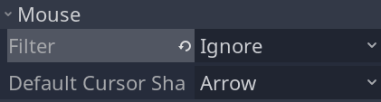

Add the following four nodes with that nested structure:

- A `TextureRect` named *Background* with its *Texture* set to `background_end_screen.png`.
  - As a child of it, a `LabelCustom` named *GameOverInfo* with the message you’d like to display in the *Text* property.
  - And a `TextureButton` named *ButtonBack* with its *Textures -> Normal* set to `button_back_normal.png` and *Textures -> Hover* set to `button_back_hover.png`.
- An `AnimationPlayer` to fade in the menu.

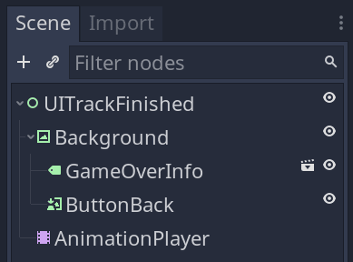

We want the *GameOverInfo* and *ButtonBack* as children of the *Background* panel to align them relative to their parent.

## Setting up the scene’s layout

Right now, our nodes are in the top-left of the viewport, but we want to align everything properly to have the panel centered on the screen.

Select the *Background* node and apply the *Layout -> Center* option to it.

[figure not shown]

Select the button and apply the *Layout -> Bottom Right* option to anchor it in the bottom-right of the *Background*.

In the *Inspector*, turn on its *Expand* property to make it scalable and scale it down a bit, as it is too large by default. You can then move it to place it inside the panel.

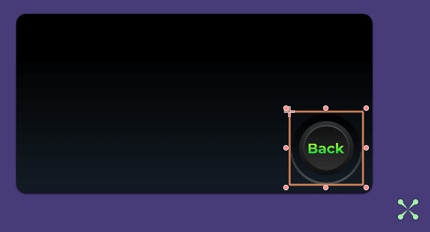

For the label, use the *Layout -> Top Wide* option to anchor it at the top of the panel. You should then resize the node horizontally to limit the textbox’s width and move it down to have the text inside the panel.

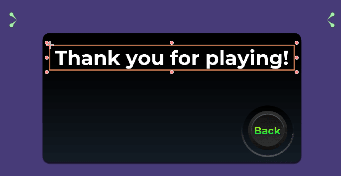

To have the text wrap and preserve the node’s width, turn on its *Autowrap* property.

This way, you can write multiple lines of text without losing your layout.

## Fading animation

We add a fade animation using the *AnimationPlayer* to animate the menu appearing. I named it *show*.

Only two properties need to change: the *Modulate*’s alpha which goes from `0` to `1.0` and *Visible*.

I added a two-second delay to the fade animation as the `Events.track_finished` signal emits as soon as the `HitSpawner` spawned the song’s last element. And we’ll use it to trigger this animation.

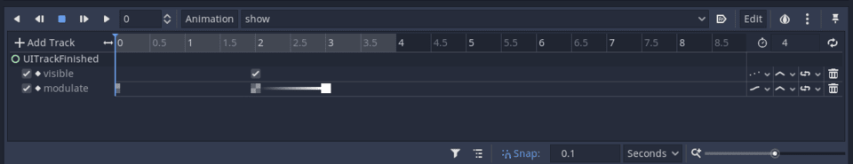

Attach a script to *UITrackFinished*. In it, we connect to `Events.track_finished` and play the animation.

```
extends Control

onready var _animation_player := $AnimationPlayer


func _ready() -> void:
    Events.connect("track_finished", self, "_on_Events_track_finished")


func _on_Events_track_finished() -> void:
    _animation_player.play("show")
```

Connect the `pressed` signal on the *ButtonBack* to `UITrackFinished.gd` to reload the scene.

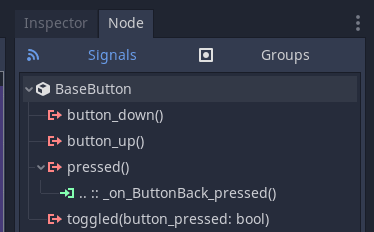

```
# ...

func _on_ButtonBack_pressed():
    get_tree().reload_current_scene()
```

Finally, instantiate the `UITrackFinished.tscn` scene to `RhythmGameDemo` and disable its visibility to complete the UI trio.

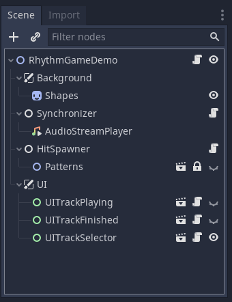

Because we emit the `track_finished` signal in `HitSpawner.gd` already when reaching the end of the track, the UI will appear and allow you to return to the main menu.

[figure not shown]

Congratulations! You have a working rhythm game!

You should have enough to adapt these concepts and techniques into your own game, but if you’d like to continue with this style of rhythm game, in the next and final lesson, we’ll build on the gameplay by adding the `HitRoller`. See you there!

## Code reference

`UITrackFinished.gd`

```
extends Control

onready var _animation_player := $AnimationPlayer


func _ready() -> void:
    Events.connect("track_finished", self, "_on_Events_track_finished")


func _on_Events_track_finished() -> void:
    _animation_player.play("show")


func _on_ButtonBack_pressed() -> void:
    get_tree().reload_current_scene()
```